# rul-predictions-DEM_Bayessian-Extended_FD002

For the train data, the RUL values are not specified, but the document regarding this dataset specifies that for the training data, all the engines were run to failure. Thus, for example, if we had five rows for a specific unit, say unit 7:

| unit | time cycle |
| --- | --- |
| 7 | 1 |
| 7 | 2 |
| 7 | 3 |
| 7 | 4 |
| 7 | 5 |

Then we know that the last row is when the RUL value becomes 0 (failure), so the RUL for this unit would be attached in this way:

| unit | time cycle | RUL |
| --- | --- | --- |
| 7 | 1 | **4** |
| 7 | 2 | **3** |
| 7 | 3 | **2** |
| 7 | 4 | **1** |
| 7 | 5 | **0** |

For the test data, we have the 'solutions' for the test engines in a separate file called rul_test (the name that I used for dataframe). I will use that to attach the RUL values for the test as well.

```python
units_training = max(df_train['unit'])
units_testing = max(df_test['unit'])
print(f'Units in the training dataset: {units_training}')
print(f'Units in the testing dataset: {units_testing}')
df_train = df_train[df_train['unit'] != 260]
if units_training > units_testing:
    df_train = df_train[df_train['unit'] <= units_testing]
elif units_training < units_testing:
    df_test = df_test[df_test['unit']  <= units_training]

assert max(df_train['unit']) == max(df_test['unit'])
no_units = max(df_train['unit'])
print(f'No of units in training and testing dataset after: {no_units}')
```

```
Units in the training dataset: 260
Units in the testing dataset: 259
No of units in training and testing dataset after: 259
```

```python
MAX_RUL = 125
no_units = min(rul_test.shape[0],max(df_train['unit']))
print(f'units :{no_units}')
```

```
units :259
```

```python
rul_list = []
engine_numbers = no_units
for n in np.arange(1,engine_numbers+1):

    time_list = np.array(df_train[df_train['unit'] == n]['time'])
    length = len(time_list)
    rul = list(length - time_list)
    rul = [min(MAX_RUL,x) for x in rul]
    rul_list += rul

df_train['rul'] = rul_list

rul_list = []

for n in np.arange(1,engine_numbers+1):

    time_list = np.array(df_test[df_test['unit'] == n]['time'])
    length = len(time_list)
    rul_val = rul_test.iloc[n-1].item()
    rul = list(length - time_list + rul_val)
    rul = [min(MAX_RUL,x) for x in rul]
    rul_list += rul

df_test['rul'] = rul_list

for df in [df_train, df_test]:
    display(df.head())
```

|  | unit | time | os1 | os2 | os3 | s1 | s2 | s3 | s4 | s5 | s6 | s7 | s8 | s9 | s10 | s11 | s12 | s13 | s14 | s15 | s16 | s17 | s18 | s19 | s20 | s21 | rul |
| --- | --- | --- | --- | --- | --- | --- | --- | --- | --- | --- | --- | --- | --- | --- | --- | --- | --- | --- | --- | --- | --- | --- | --- | --- | --- | --- | --- |
| 0 | 1 | 1 | 34.9983 | 0.8400 | 100.0 | 449.44 | 555.32 | 1358.61 | 1137.23 | 5.48 | 8.00 | 194.64 | 2222.65 | 8341.91 | 1.02 | 42.02 | 183.06 | 2387.72 | 8048.56 | 9.3461 | 0.02 | 334 | 2223 | 100.00 | 14.73 | 8.8071 | 125 |
| 1 | 1 | 2 | 41.9982 | 0.8408 | 100.0 | 445.00 | 549.90 | 1353.22 | 1125.78 | 3.91 | 5.71 | 138.51 | 2211.57 | 8303.96 | 1.02 | 42.20 | 130.42 | 2387.66 | 8072.30 | 9.3774 | 0.02 | 330 | 2212 | 100.00 | 10.41 | 6.2665 | 125 |
| 2 | 1 | 3 | 24.9988 | 0.6218 | 60.0 | 462.54 | 537.31 | 1256.76 | 1047.45 | 7.05 | 9.02 | 175.71 | 1915.11 | 8001.42 | 0.94 | 36.69 | 164.22 | 2028.03 | 7864.87 | 10.8941 | 0.02 | 309 | 1915 | 84.93 | 14.08 | 8.6723 | 125 |
| 3 | 1 | 4 | 42.0077 | 0.8416 | 100.0 | 445.00 | 549.51 | 1354.03 | 1126.38 | 3.91 | 5.71 | 138.46 | 2211.58 | 8303.96 | 1.02 | 41.96 | 130.72 | 2387.61 | 8068.66 | 9.3528 | 0.02 | 329 | 2212 | 100.00 | 10.59 | 6.4701 | 125 |
| 4 | 1 | 5 | 25.0005 | 0.6203 | 60.0 | 462.54 | 537.07 | 1257.71 | 1047.93 | 7.05 | 9.03 | 175.05 | 1915.10 | 7993.23 | 0.94 | 36.89 | 164.31 | 2028.00 | 7861.23 | 10.8963 | 0.02 | 309 | 1915 | 84.93 | 14.13 | 8.5286 | 125 |

|  | unit | time | os1 | os2 | os3 | s1 | s2 | s3 | s4 | s5 | s6 | s7 | s8 | s9 | s10 | s11 | s12 | s13 | s14 | s15 | s16 | s17 | s18 | s19 | s20 | s21 | rul |
| --- | --- | --- | --- | --- | --- | --- | --- | --- | --- | --- | --- | --- | --- | --- | --- | --- | --- | --- | --- | --- | --- | --- | --- | --- | --- | --- | --- |
| 0 | 1 | 1 | 9.9987 | 0.2502 | 100.0 | 489.05 | 605.03 | 1497.17 | 1304.99 | 10.52 | 15.49 | 394.54 | 2318.96 | 8763.80 | 1.26 | 45.61 | 371.69 | 2388.18 | 8114.10 | 8.6476 | 0.03 | 369 | 2319 | 100.00 | 28.42 | 17.1551 | 125 |
| 1 | 1 | 2 | 20.0026 | 0.7000 | 100.0 | 491.19 | 607.82 | 1481.20 | 1246.11 | 9.35 | 13.66 | 334.36 | 2323.95 | 8713.21 | 1.08 | 44.26 | 315.32 | 2388.12 | 8053.06 | 9.2405 | 0.02 | 364 | 2324 | 100.00 | 24.29 | 14.8039 | 125 |
| 2 | 1 | 3 | 35.0045 | 0.8400 | 100.0 | 449.44 | 556.00 | 1359.08 | 1128.36 | 5.48 | 8.00 | 193.55 | 2222.67 | 8340.20 | 1.02 | 41.80 | 183.04 | 2387.75 | 8053.04 | 9.3472 | 0.02 | 333 | 2223 | 100.00 | 14.98 | 8.9125 | 125 |
| 3 | 1 | 4 | 42.0066 | 0.8410 | 100.0 | 445.00 | 550.17 | 1349.69 | 1127.89 | 3.91 | 5.71 | 138.74 | 2211.58 | 8313.85 | 1.02 | 42.21 | 130.40 | 2387.72 | 8066.90 | 9.3961 | 0.02 | 332 | 2212 | 100.00 | 10.35 | 6.4181 | 125 |
| 4 | 1 | 5 | 24.9985 | 0.6213 | 60.0 | 462.54 | 536.72 | 1253.18 | 1050.69 | 7.05 | 9.03 | 175.75 | 1915.10 | 7997.13 | 0.94 | 36.76 | 164.56 | 2028.05 | 7865.66 | 10.8682 | 0.02 | 305 | 1915 | 84.93 | 14.31 | 8.5740 | 125 |

```python
from sklearn.cluster import KMeans
from sklearn.preprocessing import StandardScaler

# Initialize KMeans and StandardScaler
kmeans = KMeans(n_clusters=6, random_state=42)
scaler = StandardScaler()

# Apply clustering for specific datasets
if file_name in ['FD002.txt', 'FD004.txt']:
    # Ensure required columns are present
    if {'os1', 'os2', 'os3'}.issubset(df_train.columns):
        # Select operating conditions and scale them
        operating_conditions = df_train[['os1', 'os2', 'os3']]
        scaled_conditions = scaler.fit_transform(operating_conditions)

        # Apply k-means clustering and assign operation_mode
        df_train['operation_mode'] = kmeans.fit_predict(scaled_conditions)
    else:
        raise ValueError("Columns 'os1', 'os2', and 'os3' are missing in the dataset!")
else:
    print(f"No clustering applied for dataset {file_name}.")

if file_name in ['FD002.txt', 'FD004.txt']:
    df_test['operation_mode'] = kmeans.predict(scaler.transform(df_test[['os1', 'os2', 'os3']]))
```

```python
for df in [df_train, df_test]:
    display(df.head())
```

|  | unit | time | os1 | os2 | os3 | s1 | s2 | s3 | s4 | s5 | s6 | s7 | s8 | s9 | s10 | s11 | s12 | s13 | s14 | s15 | s16 | s17 | s18 | s19 | s20 | s21 | rul | operation_mode |
| --- | --- | --- | --- | --- | --- | --- | --- | --- | --- | --- | --- | --- | --- | --- | --- | --- | --- | --- | --- | --- | --- | --- | --- | --- | --- | --- | --- | --- |
| 0 | 1 | 1 | 34.9983 | 0.8400 | 100.0 | 449.44 | 555.32 | 1358.61 | 1137.23 | 5.48 | 8.00 | 194.64 | 2222.65 | 8341.91 | 1.02 | 42.02 | 183.06 | 2387.72 | 8048.56 | 9.3461 | 0.02 | 334 | 2223 | 100.00 | 14.73 | 8.8071 | 125 | 0 |
| 1 | 1 | 2 | 41.9982 | 0.8408 | 100.0 | 445.00 | 549.90 | 1353.22 | 1125.78 | 3.91 | 5.71 | 138.51 | 2211.57 | 8303.96 | 1.02 | 42.20 | 130.42 | 2387.66 | 8072.30 | 9.3774 | 0.02 | 330 | 2212 | 100.00 | 10.41 | 6.2665 | 125 | 5 |
| 2 | 1 | 3 | 24.9988 | 0.6218 | 60.0 | 462.54 | 537.31 | 1256.76 | 1047.45 | 7.05 | 9.02 | 175.71 | 1915.11 | 8001.42 | 0.94 | 36.69 | 164.22 | 2028.03 | 7864.87 | 10.8941 | 0.02 | 309 | 1915 | 84.93 | 14.08 | 8.6723 | 125 | 1 |
| 3 | 1 | 4 | 42.0077 | 0.8416 | 100.0 | 445.00 | 549.51 | 1354.03 | 1126.38 | 3.91 | 5.71 | 138.46 | 2211.58 | 8303.96 | 1.02 | 41.96 | 130.72 | 2387.61 | 8068.66 | 9.3528 | 0.02 | 329 | 2212 | 100.00 | 10.59 | 6.4701 | 125 | 5 |
| 4 | 1 | 5 | 25.0005 | 0.6203 | 60.0 | 462.54 | 537.07 | 1257.71 | 1047.93 | 7.05 | 9.03 | 175.05 | 1915.10 | 7993.23 | 0.94 | 36.89 | 164.31 | 2028.00 | 7861.23 | 10.8963 | 0.02 | 309 | 1915 | 84.93 | 14.13 | 8.5286 | 125 | 1 |

|  | unit | time | os1 | os2 | os3 | s1 | s2 | s3 | s4 | s5 | s6 | s7 | s8 | s9 | s10 | s11 | s12 | s13 | s14 | s15 | s16 | s17 | s18 | s19 | s20 | s21 | rul | operation_mode |
| --- | --- | --- | --- | --- | --- | --- | --- | --- | --- | --- | --- | --- | --- | --- | --- | --- | --- | --- | --- | --- | --- | --- | --- | --- | --- | --- | --- | --- |
| 0 | 1 | 1 | 9.9987 | 0.2502 | 100.0 | 489.05 | 605.03 | 1497.17 | 1304.99 | 10.52 | 15.49 | 394.54 | 2318.96 | 8763.80 | 1.26 | 45.61 | 371.69 | 2388.18 | 8114.10 | 8.6476 | 0.03 | 369 | 2319 | 100.00 | 28.42 | 17.1551 | 125 | 4 |
| 1 | 1 | 2 | 20.0026 | 0.7000 | 100.0 | 491.19 | 607.82 | 1481.20 | 1246.11 | 9.35 | 13.66 | 334.36 | 2323.95 | 8713.21 | 1.08 | 44.26 | 315.32 | 2388.12 | 8053.06 | 9.2405 | 0.02 | 364 | 2324 | 100.00 | 24.29 | 14.8039 | 125 | 3 |
| 2 | 1 | 3 | 35.0045 | 0.8400 | 100.0 | 449.44 | 556.00 | 1359.08 | 1128.36 | 5.48 | 8.00 | 193.55 | 2222.67 | 8340.20 | 1.02 | 41.80 | 183.04 | 2387.75 | 8053.04 | 9.3472 | 0.02 | 333 | 2223 | 100.00 | 14.98 | 8.9125 | 125 | 0 |
| 3 | 1 | 4 | 42.0066 | 0.8410 | 100.0 | 445.00 | 550.17 | 1349.69 | 1127.89 | 3.91 | 5.71 | 138.74 | 2211.58 | 8313.85 | 1.02 | 42.21 | 130.40 | 2387.72 | 8066.90 | 9.3961 | 0.02 | 332 | 2212 | 100.00 | 10.35 | 6.4181 | 125 | 5 |
| 4 | 1 | 5 | 24.9985 | 0.6213 | 60.0 | 462.54 | 536.72 | 1253.18 | 1050.69 | 7.05 | 9.03 | 175.75 | 1915.10 | 7997.13 | 0.94 | 36.76 | 164.56 | 2028.05 | 7865.66 | 10.8682 | 0.02 | 305 | 1915 | 84.93 | 14.31 | 8.5740 | 125 | 1 |

Standard normalization (z-score normalization), the data is scaled to have a mean of 0 and a standard deviation of 1.

```python
sensor_colums = ['s'+str(i) for i in range(1,22)]
print(sensor_colums)
```

```
['s1', 's2', 's3', 's4', 's5', 's6', 's7', 's8', 's9', 's10', 's11', 's12', 's13', 's14', 's15', 's16', 's17', 's18', 's19', 's20', 's21']
```

```python
##  Z-score Normalization
if file_name in ['FD001.txt', 'FD003.txt']:
    # Dictionary to store mean and std for columns containing 's'
    mean_std_dict = {}

    # Calculate mean and std for 's' columns in df_train
    for c in sensor_colums:
        mean_std_dict[c + '_mean'] = df_train[c].mean()
        mean_std_dict[c + '_std'] = df_train[c].std()

    # Apply standard normalization to df_train
    for c in sensor_colums:
            df_train[c] = (df_train[c] - mean_std_dict[c + '_mean']) / (mean_std_dict[c + '_std'] + 1e-6)

    # Apply standard normalization to df_test using df_train's mean and std
    for c in sensor_colums:
            df_test[c] = (df_test[c] - mean_std_dict[c + '_mean']) / (mean_std_dict[c + '_std'] + 1e-6)
```

```python
if file_name in ['FD002.txt', 'FD004.txt']:
    # Function to normalize each group based on its operation_mode
    def z_score_normalize_by_mode(group):
        group = group.copy()  # To avoid modifying the original data
        for c in sensor_colums:
            group[c] = (group[c] - group[c].mean()) / (group[c].std() + 1e-6)
        return group

    # Normalize training data
    df_train_normalized = df_train.groupby('operation_mode', group_keys=False).apply(z_score_normalize_by_mode)

    # Normalize test data using train stats for each operation_mode
    for mode in df_train['operation_mode'].unique():
        train_group = df_train[df_train['operation_mode'] == mode]
        test_group = df_test[df_test['operation_mode'] == mode]

        for c in sensor_colums:
            # Ensure the column dtype is compatible
            df_test[c] = df_test[c].astype(float)

            mean = train_group[c].mean()
            std = train_group[c].std()

            df_test.loc[df_test['operation_mode'] == mode, c] = (
                df_test.loc[df_test['operation_mode'] == mode, c] - mean
            ) / (std+1e-6)

    df_train = df_train_normalized.copy()
```

```python
if file_name in ['FD002.txt', 'FD004.txt']:
    df_train = df_train.drop('operation_mode', axis = 1)
    df_test = df_test.drop('operation_mode', axis = 1)

os_colums = ['os'+str(i) for i in range(1,4)]
print(os_colums)

mean_std_dict = {}
# Calculate mean and std for 's' columns in df_train
for c in os_colums:
    mean_std_dict[c + '_mean'] = df_train[c].mean()
    mean_std_dict[c + '_std'] = df_train[c].std()

# Apply standard normalization to df_train
for c in os_colums:
    df_train[c] = (df_train[c] - mean_std_dict[c + '_mean']) / (mean_std_dict[c + '_std'] + 1e-6)

# Apply standard normalization to df_test using df_train's mean and std
for c in os_colums:
    df_test[c] = (df_test[c] - mean_std_dict[c + '_mean']) / (mean_std_dict[c + '_std'] + 1e-6)

# Display the first few rows of both datasets
for df in [df_train, df_test]:
    display(df.head())
```

```
['os1', 'os2', 'os3']
```

|  | unit | time | os1 | os2 | os3 | s1 | s2 | s3 | s4 | s5 | s6 | s7 | s8 | s9 | s10 | s11 | s12 | s13 | s14 | s15 | s16 | s17 | s18 | s19 | s20 | s21 | rul |
| --- | --- | --- | --- | --- | --- | --- | --- | --- | --- | --- | --- | --- | --- | --- | --- | --- | --- | --- | --- | --- | --- | --- | --- | --- | --- | --- | --- |
| 0 | 1 | 1 | 0.745835 | 0.864179 | 0.418061 | 1.136868e-07 | -1.091041 | -1.442268 | 0.767886 | -8.881784e-10 | -0.172002 | 0.414295 | -1.409091 | -0.837981 | -0.201077 | 0.161557 | 0.099799 | -1.403971 | -1.540288 | 0.358858 | 0.000000e+00 | -0.167936 | 0.0 | 0.000000e+00 | -0.889803 | -1.350077 | 125 |
| 1 | 1 | 2 | 1.220498 | 0.866760 | 0.418061 | 0.000000e+00 | 0.448386 | -0.221928 | -0.266703 | 1.332268e-09 | -1.184054 | -0.272014 | -1.344538 | -1.334196 | -0.155178 | 0.211507 | -0.377958 | -1.216867 | -1.043857 | 0.059079 | 0.000000e+00 | -0.758976 | 0.0 | 0.000000e+00 | -1.631696 | -1.314162 | 125 |
| 2 | 1 | 3 | 0.067770 | 0.160340 | -2.391952 | -5.684342e-08 | 1.242838 | -1.125400 | -0.424638 | 8.881784e-10 | -1.858697 | 0.637158 | -1.177852 | -1.007012 | 0.088545 | -0.536546 | -1.023371 | -1.034022 | -1.052041 | -0.462180 | 3.469447e-12 | 1.278396 | 0.0 | -1.421085e-08 | -1.628991 | 1.721647 | 125 |
| 3 | 1 | 4 | 1.221142 | 0.869340 | 0.418061 | 0.000000e+00 | -0.452125 | -0.078114 | -0.188162 | 1.332268e-09 | -1.184054 | -0.385907 | -1.310909 | -1.334196 | -0.155178 | -0.793303 | 0.502730 | -1.372719 | -1.266719 | -0.596009 | 0.000000e+00 | -1.469067 | 0.0 | 0.000000e+00 | 0.034683 | 1.847031 | 125 |
| 4 | 1 | 5 | 0.067885 | 0.155501 | -2.391952 | -5.684342e-08 | 0.572215 | -0.945363 | -0.354104 | 8.881784e-10 | 0.536134 | -0.836580 | -1.216606 | -1.596519 | 0.088545 | 0.422942 | -0.761611 | -1.143910 | -1.335676 | -0.411166 | 3.469447e-12 | 1.278396 | 0.0 | -1.421085e-08 | -1.183058 | -0.450567 | 125 |

|  | unit | time | os1 | os2 | os3 | s1 | s2 | s3 | s4 | s5 | s6 | s7 | s8 | s9 | s10 | s11 | s12 | s13 | s14 | s15 | s16 | s17 | s18 | s19 | s20 | s21 | rul |
| --- | --- | --- | --- | --- | --- | --- | --- | --- | --- | --- | --- | --- | --- | --- | --- | --- | --- | --- | --- | --- | --- | --- | --- | --- | --- | --- | --- |
| 0 | 1 | 1 | -0.949386 | -1.038316 | 0.418061 | -1.136868e-07 | 0.242928 | -0.838184 | -0.743908 | 0.000000e+00 | -0.700137 | 0.322429 | 0.013938 | -1.192453 | 0.019211 | 0.481647 | 0.459288 | 0.181946 | -1.319893 | -0.448464 | -1.040834e-11 | -0.471416 | 0.0 | 0.000000e+00 | -0.736388 | 0.459398 | 125 |
| 1 | 1 | 2 | -0.271022 | 0.412587 | 0.418061 | 1.136868e-07 | 0.549340 | -0.759980 | -0.901197 | 1.776357e-09 | 0.711186 | -0.223175 | -0.566626 | -0.966775 | 0.541651 | -0.793310 | 0.899749 | -0.263669 | -0.851829 | 0.197927 | -5.228824e-01 | -0.943899 | 0.0 | 0.000000e+00 | -1.213522 | 1.644883 | 125 |
| 2 | 1 | 3 | 0.746255 | 0.864179 | 0.418061 | 1.136868e-07 | 0.456540 | -1.358632 | -0.430256 | -8.881784e-10 | -0.172002 | -1.873362 | -1.336677 | -0.939530 | -0.201077 | -0.794553 | 0.046613 | -1.302880 | -1.247410 | 0.387682 | 0.000000e+00 | -0.880128 | 0.0 | 0.000000e+00 | 1.319888 | 0.219312 | 125 |
| 3 | 1 | 4 | 1.221067 | 0.867405 | 0.418061 | 0.000000e+00 | 1.071817 | -0.848672 | 0.009502 | 1.332268e-09 | -1.184054 | 0.251898 | -1.310909 | -0.780769 | -0.155178 | 0.253375 | -0.436671 | -1.029844 | -1.374477 | 0.557052 | 0.000000e+00 | 0.661205 | 0.0 | 0.000000e+00 | -2.187156 | 1.039654 | 125 |
| 4 | 1 | 5 | 0.067749 | 0.158727 | -2.391952 | -5.684342e-08 | -0.405778 | -1.803852 | 0.051462 | 8.881784e-10 | 0.536134 | 0.726475 | -1.216606 | -1.315802 | 0.088545 | -0.200725 | -0.034498 | -0.960764 | -0.990483 | -1.062757 | 3.469447e-12 | -1.821018 | 0.0 | -1.421085e-08 | 0.422298 | 0.235714 | 125 |

Below, we can see an example of all the sensor values of a specific engine in the training set (unit 4), as the engine progresses toward failure.

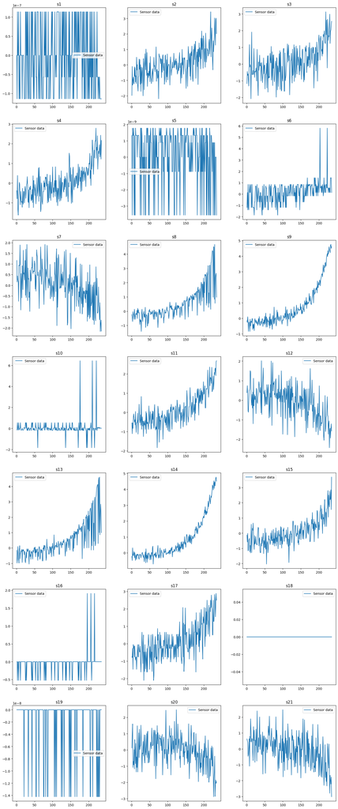

```python
sample = 4
sample_df = df_train[df_train['unit'] == sample].copy()

# Select only sensor columns
n_sensors = len(sensor_colums)
rows = (n_sensors + 2) // 3  # Calculate rows for the grid

# Create subplots
fig, axes = plt.subplots(rows, 3, figsize=(15, 5 * rows))

# Flatten axes for easier iteration
axes = axes.flatten()

# Plot each sensor's data
for j, c in enumerate(sensor_colums):
    axes[j].plot(sample_df['time'], sample_df[c], label='Sensor data')
    axes[j].set_title(c)
    # axes[j].set_xlabel('Time')
    # axes[j].set_ylabel('Value')
    axes[j].legend()

# Hide unused subplots
for ax in axes[n_sensors:]:
    ax.axis('off')

# Adjust layout for better spacing
fig.tight_layout(pad=3.0)
plt.savefig(f'figures\\sensor_of_engine_{sample}_for_dataset_{file_name}.png', dpi=300, bbox_inches='tight')
plt.show()
```

We plot the sensor data obtained from sensor 2 for 5 of the engines to show a general trend.

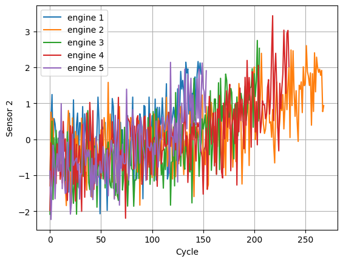

```python
sensor = 's2'
for sample in range(1,6):
    sample_df = df_train[df_train['unit'] == sample].copy()
    sensordata = sample_df[sensor].to_numpy()
    plt.plot(sensordata, label = "engine "+str(sample))
plt.grid()
plt.legend()
plt.ylabel('Sensor 2')
plt.xlabel('Cycle')
plt.savefig(f'figures\\sensor_{sensor}_of_engines_for_dataset_{file_name}.png', dpi=300, bbox_inches='tight')
plt.show()
```